**Embedded Systems**

By Prof. Seungchul Lee  
http://iai.postech.ac.kr/  
Industrial AI Lab at POSTECH

Table of Contents

# 1. Embedded Systems

Embedded systems are a ubiquitous component of our everyday lives.

- An embedded system is a system that performs a specific task and has a computer embedded inside. A system is comprised of components and interfaces connected together for a common purpose.
- An embedded system is a microcomputer with mechanical, chemical, or electrical devices attached to it, programmed for a specific dedicated purpose, and packaged up as a complete system.

```python
%%html
<iframe src="https://www.youtube.com/embed/ZoHjGRtl39s"
width="560" height="315" frameborder="0" allowfullscreen></iframe>
```

[video not shown]

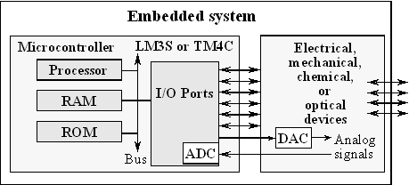

- Embedded Systems
  - physical world
  - limited resources
  - limited context
- The Internet (IoT)
  - Cyber world
  - Unlimited resources
  - rich context

# 2. Internet of Things (IoT)

- But, the Internet part of IoT will not be covered in this class.

```python
%%html
<iframe src="https://www.youtube.com/embed/ItNGi3-CJZE"
width="560" height="315" frameborder="0" allowfullscreen></iframe>
```

[video not shown]

```python
%%html
<iframe src="https://www.youtube.com/embed/7xA7pQpccYA"
width="560" height="315" frameborder="0" allowfullscreen></iframe>
```

[video not shown]

```python
%%html
<iframe src="https://www.youtube.com/embed/Q3ur8wzzhBU"
width="560" height="315" frameborder="0" allowfullscreen></iframe>
```

[video not shown]

```python
%%html
<iframe src="https://www.youtube.com/embed/NjYTzvAVozo"
width="560" height="315" frameborder="0" allowfullscreen></iframe>
```

[video not shown]

```python
%%html
<iframe src="https://www.youtube.com/embed/_AlcRoqS65E"
width="560" height="315" frameborder="0" allowfullscreen></iframe>
```

[video not shown]

# 3. Microcontroller (MCU/CPU)

- Microcontrollers have basic computing functionality
- Many onboard I/O subsystems
  - General Purpose IO (GPIO)
  - A/D and D/A
  - Interrupts
  - Clocks/Timers
  - Buses
- Every pin maps to one or more subsystems

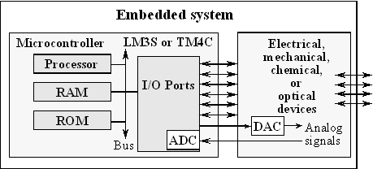

# 4. Prerequisites

- circuit theory
- digital logic theory
- programming skills
- signal processing and control

But do not worry !!! I will build this class while assuming students having no prior knowledge above

# 5. What can We Do After Taking this Class?

Motor (Robotics)

```python
%%html
<iframe src="https://www.youtube.com/embed/jTh6TVKgAtM?list=PLBD_gON7g_m3th-gxjQRma1z-1Cc8M7t4"
width="560" height="315" frameborder="0" allowfullscreen></iframe>
```

[video not shown]

Control (Quadcopter or drone)

```python
%%html
<iframe src="https://www.youtube.com/embed/N8UX_TDMn-Y?list=PLBD_gON7g_m3th-gxjQRma1z-1Cc8M7t4"
width="560" height="315" frameborder="0" allowfullscreen></iframe>
```

[video not shown]

Teleoperation Robotics: input and output

```python
%%html
<iframe src="https://www.youtube.com/embed/Ci4mC01o5t0"
width="560" height="315" frameborder="0" allowfullscreen></iframe>
```

[video not shown]

Dancing Robot: signal processing + robotics

```python
%%html
<iframe src="https://www.youtube.com/embed/snMTiPywoiM?list=PLBD_gON7g_m3th-gxjQRma1z-1Cc8M7t4"
width="560" height="315" frameborder="0" allowfullscreen></iframe>
```

[video not shown]

XY Plotter: image processing + robotics

```python
%%html
<iframe src="https://www.youtube.com/embed/_RAF2D_DYYQ?list=PLBD_gON7g_m3th-gxjQRma1z-1Cc8M7t4"
width="560" height="315" frameborder="0" allowfullscreen></iframe>
```

[video not shown]

Drone: image processing + PID control

```python
%%html
<iframe src="https://www.youtube.com/embed/QjVA8W1L9Ro?list=PLBD_gON7g_m3th-gxjQRma1z-1Cc8M7t4"
width="560" height="315" frameborder="0" allowfullscreen></iframe>
```

[video not shown]

```python
%%javascript
$.getScript('https://kmahelona.github.io/ipython_notebook_goodies/ipython_notebook_toc.js')
```